# Aoyama OE2 - Spring Semester 2026

Chris Elvin

2026-06-18

### Today

#### Warmup question

```
[1] "What time did you go to bed last night?"
```

| name | answer |
| --- | --- |
| KONDO AN | I have a cold; I have a high fever and a bad cough, and I also have a terrible headache and sore throat. Therefore, I will be absent from class today. I’m sorry. |
| YUZAWA SANA | AM0:00 |
| YAMAGUCHI KAHO | 2a.m. |
| KIMURA HARUA | I went to bed at 2 am. |
| TAKAHASHI SAKI | I went to bed at 2 AM yesterday. |
| SAKANASHI KANO | I went to go bed at 0:00 |
| YAJIMA KOUDAI | I go to bed at 0:00 |
| TEJIMA SEIYA | at midnight |
| KIHARA MOE | I went to the bed at midnight yesterday. |
| SAKAE AKARI | I went to bed at 11. I had part-time job yesterday. |
| KUJIRAOKA SERA | I went to bed at 11 p.m. yesterday. |
| CHIKUMA KAHO | I went to bed 2 am. |
| AKIYAMA RURUKO | I went to bed at 4 a.m. |
| MATSUHISA HONOKA | I went to bed at eleven. |
| TAKEMOTO MEIBI | I went to bed at twelve thirty. |
| ONISHI NANAKA | I went to bed at 0am. |
| KUBOTA ANNA | I went to bed at eleven thirty. |
| INO YUYA | 2:00 A.M. |
| FUKAYA MINA | I went to the bed at 12 o’clock. |
| OTANI WASEI | I went to bed at 12 o’clock |
| SAITOU MIREI | I went to bed at 1:00. |
| TEZUKA ASUMI | I went to bed at 11 p.m. |
| SAWADA MANATO | l went to bed at 11p.m. |
| KOJIMA TAKUMI | 11pm |
| YAHAGI AYA | 2am |

#### Discussion Leader Feedback

| leader | preparation | content | fluency | communication | pronunciation | TOTAL |
| --- | --- | --- | --- | --- | --- | --- |
| NONOKA | 5.0 | 5.0 | 5.0 | 5.0 | 5.0 | 25.0 |
| RURUKO | 5.0 | 5.0 | 5.0 | 5.0 | 5.0 | 25.0 |
| TAKUMI | 4.6 | 4.6 | 4.6 | 4.7 | 4.5 | 23.0 |
| AKARI | 4.7 | 4.5 | 4.6 | 4.6 | 4.3 | 22.7 |
| NANAKA | 4.5 | 4.6 | 4.5 | 4.5 | 4.5 | 22.6 |
| SANA | 4.6 | 4.4 | 4.4 | 4.6 | 4.5 | 22.5 |
| HONOKA | 4.8 | 4.6 | 4.3 | 4.5 | 4.2 | 22.4 |
| KAHO | 4.4 | 4.4 | 4.3 | 4.6 | 4.4 | 22.1 |

#### Preparation

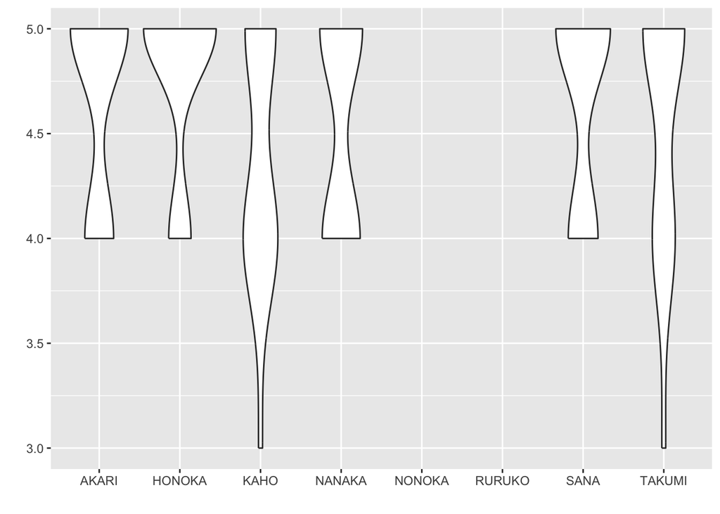

#### Content

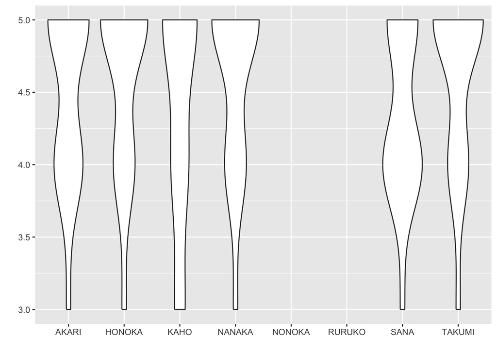

#### Fluency

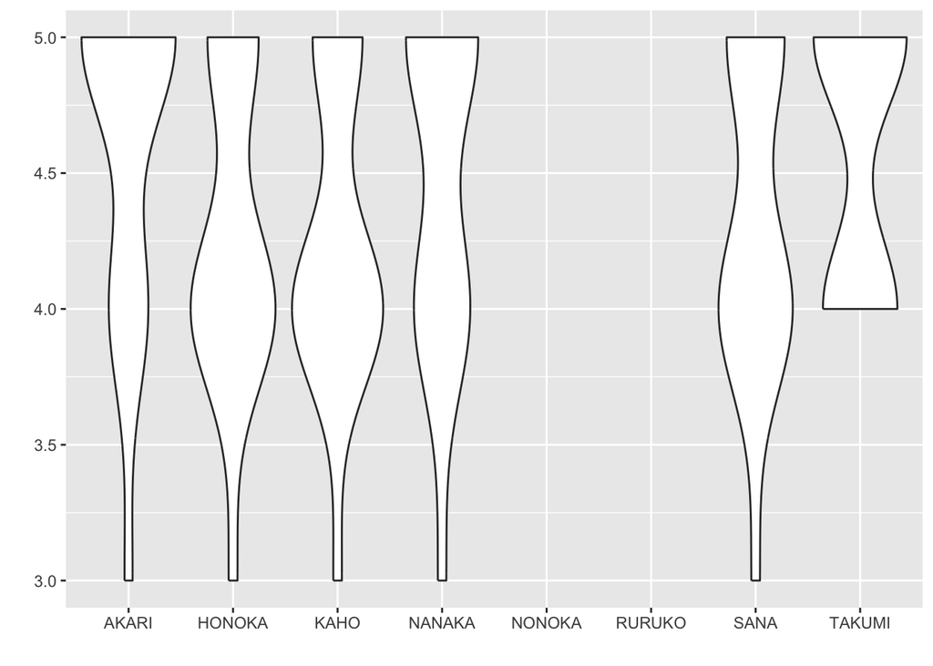

#### Communication

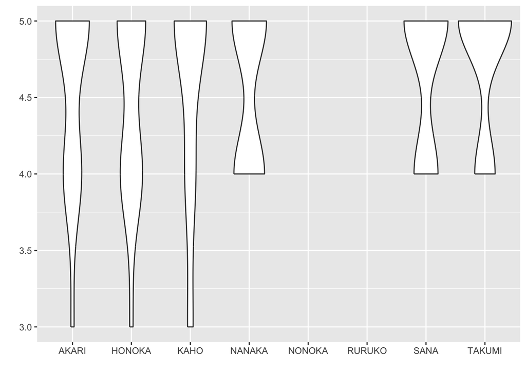

#### Pronunciation

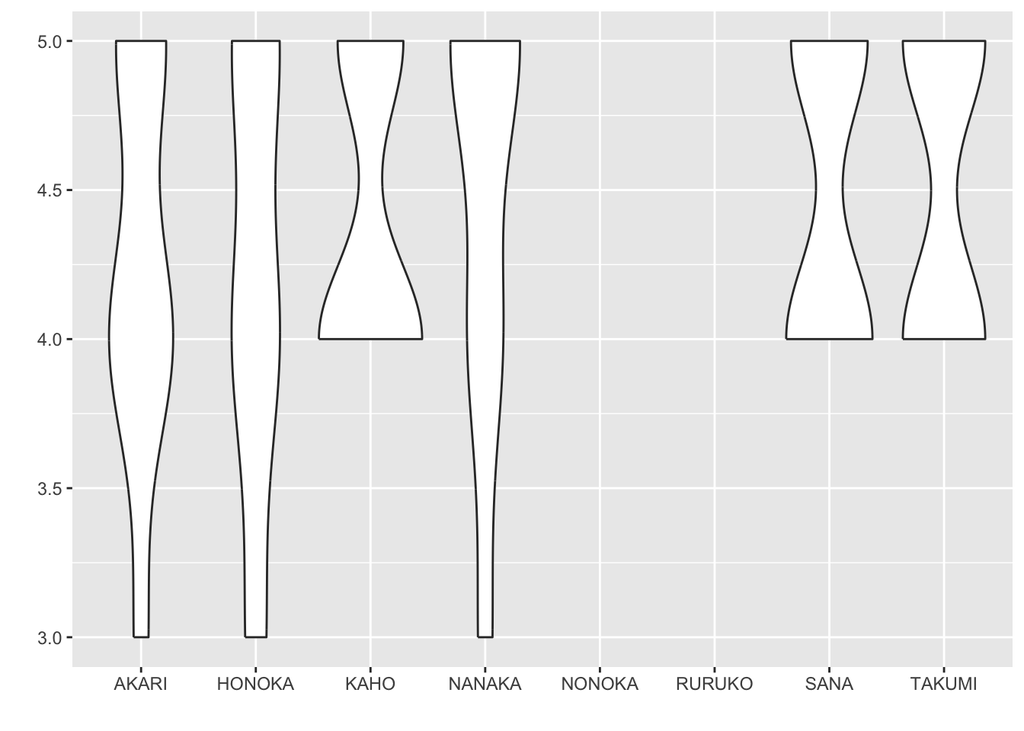

#### Presentation Feedback

[figure not shown]

#### What did you like best about her presentation?

```
< table of extent 0 x 0 >
```

#### What else did you like about her presentation?

```
< table of extent 0 x 0 >
```

#### Improvement suggestion

```
< table of extent 0 x 0 >
```

#### When did you submit today’s form?

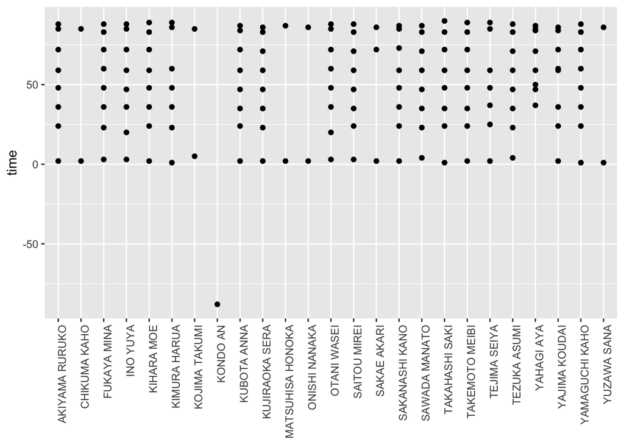

#### What was your role today?

```
                  role
name                 discussion leader participant
  AKIYAMA RURUKO   7                 0           1
  CHIKUMA KAHO     1                 1           0
  FUKAYA MINA      7                 0           1
  INO YUYA         8                 0           0
  KIHARA MOE       7                 0           1
  KIMURA HARUA     6                 0           1
  KOJIMA TAKUMI    1                 1           0
  KONDO AN         1                 0           0
  KUBOTA ANNA      7                 0           1
  KUJIRAOKA SERA   7                 0           1
  MATSUHISA HONOKA 1                 1           0
  ONISHI NANAKA    1                 1           0
  OTANI WASEI      7                 0           1
  SAITOU MIREI     7                 0           1
  SAKAE AKARI      2                 1           0
  SAKANASHI KANO   7                 0           1
  SAWADA MANATO    7                 0           1
  TAKAHASHI SAKI   7                 0           1
  TAKEMOTO MEIBI   7                 0           1
  TEJIMA SEIYA     6                 0           1
  TEZUKA ASUMI     7                 0           1
  YAHAGI AYA       7                 0           1
  YAJIMA KOUDAI    7                 0           1
  YAMAGUCHI KAHO   7                 0           1
  YUZAWA SANA      1                 1           0
```

#### Today’s key words

```
 [1] allergies     annoying      balance       burden        choice
 [6] concentration diversity     financially   global        happiness
[11] high school   independent   information   knowing       morning
[16] nutrition     scary         secret
19 Levels:  allergies annoying balance burden choice ... secret
```

#### Today’s vocabulary homework challenge

```
[1] allergies annoying  burden    choice    knowing
19 Levels:  allergies annoying balance burden choice ... secret
```

### Reflection

#### How was today?

```
today
great!   good
     9      8
```

```
good
   1
```

#### What was good about today’s lesson?

comment

I was able to share my opinion first.

We can use the new vocabulary words what we can not use before

Enjoy talking

Discussion is fun.

- I was able to communicate well.

Because the topic was interesting.

There were interesting contents so much.

Good communication

I can speak my thinking more than before in English.

I could express my opinions fluently compared to usual.

There are many kinds of topics and the topics were so interesting.

Each topic is interesting for me.

I could know other’s opinions.

We could discuss many interesting topics.

I could think carefully to talk.

My opinion was interesting.

I could tell my opinion with correct grammar.

| comment |
| --- |
| We can do good discussion. |

#### What was not so good?

| comment |
| --- |
| I couldn’t speak smoothly. |
| Nothing |
| Nothing |
| Nothing |
| I couldn’t think independently and often relied on others opinions. |
| It was difficult to convert Japanese into English. |
| I became be tired gradually. |
| Sometimes I speak Japanese. |
| Sometimes I couldn’t remember vocabularies. |
| The discussions were not fulfilling. |
| When I told my opinion, sometimes I don’t explain my mind. |
| I sometimes talked topic that was different from discussion leader’s topic. |
| I could not talk fluently. |
| Nothing in particular. |
| I could not speak fluently very much. |
| I wasn’t clam and I often speak Japanese |
| Sometimes it was difficult to choose correct words. |

| comment |
| --- |
| I sometimes use Japanese. |

#### Who was interesting?

```
gold
     SAKAE AKARI MATSUHISA HONOKA    KOJIMA TAKUMI      YUZAWA SANA
               5                4                4                3
    CHIKUMA KAHO
               1
```

```
CHIKUMA KAHO
           1
```

| gold | reason |
| --- | --- |
| CHIKUMA KAHO | The topic was close to us |
| KOJIMA TAKUMI | He prepared a lot of questions. |
| KOJIMA TAKUMI | His talk theme was deeply and the discussion was interested. |
| KOJIMA TAKUMI | The topic was interesting. |
| KOJIMA TAKUMI | interesting topic |
| MATSUHISA HONOKA | Because I’m interested in psychology. |
| MATSUHISA HONOKA | Because her speaking made me feel relax so I was clam |
| MATSUHISA HONOKA | Making many question |
| MATSUHISA HONOKA | Psychology topic was good |
| SAKAE AKARI | Because her topic can remind me of past experience. It was fun for me. |
| SAKAE AKARI | Because the discussion had been prepared well. |
| SAKAE AKARI | Her topic was interesting and the questions were so prepared. |
| SAKAE AKARI | This students topics so intersting |
| SAKAE AKARI | Very prepared. |
| YUZAWA SANA | Because the topic was easy to talk about. |
| YUZAWA SANA | Her communication skills are very good and the topic was most interesting. |
| YUZAWA SANA | She prepared a lot of simple question, so I can easily discuss. |

| gold | reason |
| --- | --- |
| CHIKUMA KAHO | She prepared many questions. |

#### Who else was interesting?

```
silver
MATSUHISA HONOKA    ONISHI NANAKA     CHIKUMA KAHO      YUZAWA SANA
               5                3                3                2
     SAKAE AKARI    KOJIMA TAKUMI
               2                2
```

```
MATSUHISA HONOKA
               1
```

silver

reason

CHIKUMA KAHO

- Because it was a topic related to our daily lives, the conversation expanded easily.

CHIKUMA KAHO

The topic was nice.

CHIKUMA KAHO

interesting topic

KOJIMA TAKUMI

His comments were accurate.

KOJIMA TAKUMI

It was worth discussing because it was difficult to define.

MATSUHISA HONOKA

Because I could think some imagination. It was exciting.

MATSUHISA HONOKA

Because the content of discussion was good.

MATSUHISA HONOKA

I learned about psychology.

MATSUHISA HONOKA

The topic was interesting

MATSUHISA HONOKA

This students prepare many discussion questions

ONISHI NANAKA

Interesting topic

ONISHI NANAKA

Interesting topic for me.

ONISHI NANAKA

She told her opinion a lot.

SAKAE AKARI

Her topic was fun for discussion.

SAKAE AKARI

The topic was close to our school life so it was easy to discuss.

YUZAWA SANA

Easy topic to talk about.

YUZAWA SANA

Her opinion was interesting.

| silver | reason |
| --- | --- |
| MATSUHISA HONOKA | the topic is very interesting. |

### Participation

#### Warmup question counts

```
name
        KONDO AN     TEZUKA ASUMI   TAKEMOTO MEIBI   TAKAHASHI SAKI
              11               10               10               10
  SAKANASHI KANO      SAKAE AKARI MATSUHISA HONOKA   KUJIRAOKA SERA
              10               10               10               10
    KIMURA HARUA       KIHARA MOE      FUKAYA MINA     CHIKUMA KAHO
              10               10               10               10
  AKIYAMA RURUKO      YUZAWA SANA YOSHIZAWA NONOKA    YAJIMA KOUDAI
              10                9                9                9
     OTANI WASEI    ONISHI NANAKA    KOJIMA TAKUMI   YAMAGUCHI KAHO
               9                9                9                8
      YAHAGI AYA         INO YUYA       ABE HIKARI     TEJIMA SEIYA
               8                8                8                7
   SAWADA MANATO     SAITOU MIREI     NEGISHI HANA      KUBOTA ANNA
               7                7                7                6
```

```
                  week
name               16 17 18 19 20 21 22 23 24 25
  ABE HIKARI        1  1  0  1  1  1  1  1  1  0
  AKIYAMA RURUKO    1  1  1  1  1  1  1  1  1  1
  CHIKUMA KAHO      1  1  1  1  1  1  1  1  1  1
  FUKAYA MINA       1  1  1  1  1  1  1  1  1  1
  INO YUYA          1  1  1  0  1  1  1  1  0  1
  KIHARA MOE        1  1  1  1  1  1  1  1  1  1
  KIMURA HARUA      1  1  1  1  1  1  1  1  1  1
  KOJIMA TAKUMI     1  1  1  1  1  1  0  1  1  1
  KONDO AN          1  1  2  1  1  1  1  1  1  1
  KUBOTA ANNA       1  1  1  0  0  1  0  1  0  1
  KUJIRAOKA SERA    1  1  1  1  1  1  1  1  1  1
  MATSUHISA HONOKA  1  1  1  1  1  1  1  1  1  1
  NEGISHI HANA      1  1  1  0  1  1  1  1  0  0
  ONISHI NANAKA     1  1  1  1  1  0  1  1  1  1
  OTANI WASEI       1  1  1  1  0  1  1  1  1  1
  SAITOU MIREI      1  1  0  1  1  0  1  0  1  1
  SAKAE AKARI       1  1  1  1  1  1  1  1  1  1
  SAKANASHI KANO    1  1  1  1  1  1  1  1  1  1
  SAWADA MANATO     1  0  1  1  0  1  1  1  0  1
  TAKAHASHI SAKI    1  1  1  1  1  1  1  1  1  1
  TAKEMOTO MEIBI    1  1  1  1  1  1  1  1  1  1
  TEJIMA SEIYA      1  1  1  0  1  1  1  0  0  1
  TEZUKA ASUMI      1  1  1  1  1  1  1  1  1  1
  YAHAGI AYA        1  1  0  0  1  1  1  1  1  1
  YAJIMA KOUDAI     1  1  1  1  0  1  1  1  1  1
  YAMAGUCHI KAHO    1  1  1  0  1  1  1  1  0  1
  YOSHIZAWA NONOKA  1  1  1  1  1  1  1  1  1  0
  YUZAWA SANA       1  0  1  1  1  1  1  1  1  1
```

#### Discussion feedback counts

```
name
    TEZUKA ASUMI      FUKAYA MINA   AKIYAMA RURUKO       KIHARA MOE
              40               40               39               36
  TAKAHASHI SAKI   SAKANASHI KANO      SAKAE AKARI   KUJIRAOKA SERA
              34               34               34               34
YOSHIZAWA NONOKA   TAKEMOTO MEIBI      OTANI WASEI    ONISHI NANAKA
              33               33               33               33
MATSUHISA HONOKA    KOJIMA TAKUMI     CHIKUMA KAHO     KIMURA HARUA
              33               33               33               32
        KONDO AN      YUZAWA SANA    YAJIMA KOUDAI   YAMAGUCHI KAHO
              30               29               29               27
    SAITOU MIREI       ABE HIKARI       YAHAGI AYA      KUBOTA ANNA
              27               24               23               23
        INO YUYA     NEGISHI HANA     TEJIMA SEIYA    SAWADA MANATO
              23               22               21               16
```

```
                  week
name               16 17 18 19 20 21 22 23 24 25
  ABE HIKARI        4  5  0  4  5  0  0  6  0  0
  AKIYAMA RURUKO    6  0  5  4  5  0  1  6  6  6
  CHIKUMA KAHO      6  6  0  4  5  0  0  6  6  0
  FUKAYA MINA       6  6  5  0  5  0  0  6  6  6
  INO YUYA          5  6  5  0  1  0  0  0  0  6
  KIHARA MOE        1  6  4  4  4  0  0  6  5  6
  KIMURA HARUA      6  1  5  4  5  0  0  6  0  5
  KOJIMA TAKUMI     6  6  0  4  5  0  0  6  6  0
  KONDO AN          6  6  8  0  5  0  0  5  0  0
  KUBOTA ANNA       6  6  5  0  0  0  0  0  0  6
  KUJIRAOKA SERA    6  6  5  4  1  0  0  0  6  6
  MATSUHISA HONOKA  6  6  5  4  0  0  0  6  6  0
  NEGISHI HANA      5  6  5  0  0  0  0  6  0  0
  ONISHI NANAKA     6  6  5  4  0  0  0  6  6  0
  OTANI WASEI       6  6  5  4  0  0  0  6  0  6
  SAITOU MIREI      6  0  0  4  5  0  0  0  6  6
  SAKAE AKARI       6  6  0  4  5  0  0  6  6  1
  SAKANASHI KANO    6  6  5  0  5  0  0  6  0  6
  SAWADA MANATO     1  0  5  4  0  0  0  0  0  6
  TAKAHASHI SAKI    6  6  5  0  4  0  0  1  6  6
  TAKEMOTO MEIBI    0  6  5  4  5  0  0  6  1  6
  TEJIMA SEIYA      6  0  5  0  5  0  0  0  0  5
  TEZUKA ASUMI      6  6  1  4  5  0  0  6  6  6
  YAHAGI AYA        6  0  0  0  5  0  0  0  6  6
  YAJIMA KOUDAI     6  5  0  4  0  2  0  6  0  6
  YAMAGUCHI KAHO    0  5  5  0  5  0  0  6  0  6
  YOSHIZAWA NONOKA  6  1  6  4  5  0  0  5  6  0
  YUZAWA SANA       2  0  6  4  5  0  0  6  6  0
```

#### Presentation feedback counts

```
name
    TEJIMA SEIYA   TAKAHASHI SAKI     KIMURA HARUA         INO YUYA
              28               28               28               28
YOSHIZAWA NONOKA   YAMAGUCHI KAHO       YAHAGI AYA     TEZUKA ASUMI
              27               27               27               27
  TAKEMOTO MEIBI    SAWADA MANATO      SAKAE AKARI      OTANI WASEI
              27               27               27               27
    NEGISHI HANA MATSUHISA HONOKA   KUJIRAOKA SERA    KOJIMA TAKUMI
              27               27               27               27
    CHIKUMA KAHO   AKIYAMA RURUKO       ABE HIKARI      YUZAWA SANA
              27               27               27               26
        KONDO AN      FUKAYA MINA   SAKANASHI KANO       KIHARA MOE
              26               26               25               25
   YAJIMA KOUDAI     SAITOU MIREI    ONISHI NANAKA      KUBOTA ANNA
              23               14               13               12
```

```
                  week
name               21 22
  ABE HIKARI       12 15
  AKIYAMA RURUKO   13 14
  CHIKUMA KAHO     12 15
  FUKAYA MINA      11 15
  INO YUYA         13 15
  KIHARA MOE       12 13
  KIMURA HARUA     13 15
  KOJIMA TAKUMI    13 14
  KONDO AN         12 14
  KUBOTA ANNA      12  0
  KUJIRAOKA SERA   13 14
  MATSUHISA HONOKA 13 14
  NEGISHI HANA     12 15
  ONISHI NANAKA     0 13
  OTANI WASEI      13 14
  SAITOU MIREI      0 14
  SAKAE AKARI      12 15
  SAKANASHI KANO   13 12
  SAWADA MANATO    12 15
  TAKAHASHI SAKI   13 15
  TAKEMOTO MEIBI   13 14
  TEJIMA SEIYA     13 15
  TEZUKA ASUMI     12 15
  YAHAGI AYA       12 15
  YAJIMA KOUDAI    10 13
  YAMAGUCHI KAHO   13 14
  YOSHIZAWA NONOKA 13 14
  YUZAWA SANA      13 13
```

#### How was today counts

```
name
     YUZAWA SANA     TEZUKA ASUMI   TAKEMOTO MEIBI   TAKAHASHI SAKI
              10               10               10               10
  SAKANASHI KANO      SAKAE AKARI MATSUHISA HONOKA   KUJIRAOKA SERA
              10               10               10               10
   KOJIMA TAKUMI       KIHARA MOE     CHIKUMA KAHO   AKIYAMA RURUKO
              10               10               10               10
YOSHIZAWA NONOKA    YAJIMA KOUDAI      OTANI WASEI     KIMURA HARUA
               9                9                9                9
     FUKAYA MINA   YAMAGUCHI KAHO       YAHAGI AYA    ONISHI NANAKA
               9                8                8                8
        KONDO AN         INO YUYA       ABE HIKARI     TEJIMA SEIYA
               8                8                8                7
   SAWADA MANATO     SAITOU MIREI     NEGISHI HANA      KUBOTA ANNA
               7                7                7                6
```

```
                  week
name               16 17 18 19 20 21 22 23 24 25
  ABE HIKARI        1  1  0  1  1  1  1  1  1  0
  AKIYAMA RURUKO    1  1  1  1  1  1  1  1  1  1
  CHIKUMA KAHO      1  1  1  1  1  1  1  1  1  1
  FUKAYA MINA       1  1  1  1  0  1  1  1  1  1
  INO YUYA          1  1  1  0  1  1  1  1  0  1
  KIHARA MOE        1  1  1  1  1  1  1  1  1  1
  KIMURA HARUA      1  1  1  1  0  1  1  1  1  1
  KOJIMA TAKUMI     1  1  1  1  1  1  1  1  1  1
  KONDO AN          1  1  1  1  1  1  1  1  0  0
  KUBOTA ANNA       1  1  1  0  0  1  0  1  0  1
  KUJIRAOKA SERA    1  1  1  1  1  1  1  1  1  1
  MATSUHISA HONOKA  1  1  1  1  1  1  1  1  1  1
  NEGISHI HANA      1  1  1  0  1  1  1  1  0  0
  ONISHI NANAKA     1  1  1  1  0  0  1  1  1  1
  OTANI WASEI       1  1  1  1  0  1  1  1  1  1
  SAITOU MIREI      1  1  0  1  1  0  1  0  1  1
  SAKAE AKARI       1  1  1  1  1  1  1  1  1  1
  SAKANASHI KANO    1  1  1  1  1  1  1  1  1  1
  SAWADA MANATO     1  0  1  1  0  1  1  1  0  1
  TAKAHASHI SAKI    1  1  1  1  1  1  1  1  1  1
  TAKEMOTO MEIBI    1  1  1  1  1  1  1  1  1  1
  TEJIMA SEIYA      1  1  1  0  1  1  1  0  0  1
  TEZUKA ASUMI      1  1  1  1  1  1  1  1  1  1
  YAHAGI AYA        1  1  0  0  1  1  1  1  1  1
  YAJIMA KOUDAI     1  1  1  1  0  1  1  1  1  1
  YAMAGUCHI KAHO    1  1  1  0  1  1  1  1  0  1
  YOSHIZAWA NONOKA  1  1  1  1  1  1  1  1  1  0
  YUZAWA SANA       2  0  1  1  1  1  1  1  1  1
```

### Term report

#### All vocabulary

```
  [1] abroad            accident          air plane         allergies
  [5] annoying          assignment        atmosphere        automation
  [9] balance           bullying          burden            cashless
 [13] characteristic    childish          choice            clothing
 [17] communication     community         competition       comprehensive
 [21] compulsory        concentration     conflict          consultation
 [25] consumption       countryside       creation          crime
 [29] critical thinking decision          despite           directly
 [33] disappear         dislike           diversity         elder
 [37] elderly           electric car      embarrassing      employee
 [41] empower           enjoyable         exercise          experience
 [45] externally        extra             extroverted       face to face
 [49] fashion           fashionable       feedback          financially
 [53] fresh             fuel              generate          global
 [57] globalized        government        happiness         harmful
```

[output cut: 17 more lines]

#### Punctuality

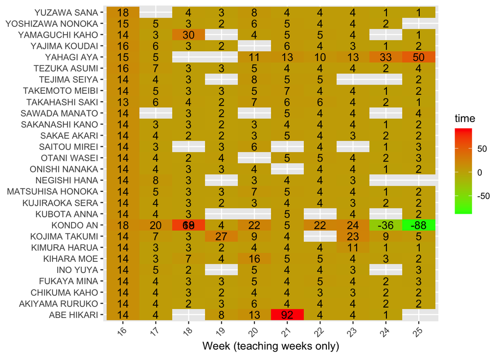

#### Current participation score out of 35

```
               name Freq errors violations sub_total total
1        ABE HIKARI   67      4          0        59  24.0
2    AKIYAMA RURUKO   86      0          0        86  35.0
3      CHIKUMA KAHO   80      0          0        80  32.6
4       FUKAYA MINA   85      0          0        85  34.6
5          INO YUYA   67      0          0        67  27.3
6        KIHARA MOE   81      1          0        79  32.2
7      KIMURA HARUA   79      1          0        77  31.3
8     KOJIMA TAKUMI   79      0          0        79  32.2
9          KONDO AN   75      3          0        69  28.1
10      KUBOTA ANNA   47      0          0        47  19.1
11   KUJIRAOKA SERA   81      0          0        81  33.0
12 MATSUHISA HONOKA   80      0          0        80  32.6
13     NEGISHI HANA   63      0          0        63  25.6
14    ONISHI NANAKA   63      0          0        63  25.6
15      OTANI WASEI   78      0          0        78  31.7
16     SAITOU MIREI   55      0          0        55  22.4
17      SAKAE AKARI   81      0          0        81  33.0
18   SAKANASHI KANO   79      0          0        79  32.2
19    SAWADA MANATO   57      1          0        55  22.4
20   TAKAHASHI SAKI   82      1          0        80  32.6
21   TAKEMOTO MEIBI   80      1          0        78  31.7
22     TEJIMA SEIYA   63      0          0        63  25.6
23     TEZUKA ASUMI   87      1          0        85  34.6
24       YAHAGI AYA   66      0          0        66  26.9
25    YAJIMA KOUDAI   70      0          0        70  28.5
26   YAMAGUCHI KAHO   70      0          0        70  28.5
27 YOSHIZAWA NONOKA   78      1          0        76  30.9
28      YUZAWA SANA   74      3          0        68  27.7
```

*Thank you for your diligence, your honesty, and your participation!*